# Risk Prediction

Jonathon Sun

10/25/2021

# Risk of Within Family Crime

(Butterfield 2018) I argue that crime within family is underreported because children and other family members may not be in a position of power to address these issues. Additionally, despite the family member committing a crime, they may be committing the crime for financial or citizenship reasons. Family members would be the individuals closest to where the crime is occurring; however, would not be reporting nor would this crime be noticed by other individuals.

To evaluate whether crime within family is under reported, I have created a model, using gambling incidents, wards, and quintile of percent of people of color per census tract. Data for within family crimes and gambling were from https://www.opendataphilly.org/dataset/crime-incidents. Ward data was pulled from https://esri-philadelphia-office.hub.arcgis.com/datasets/d67c97376d18456d98e5fa6e00415ad4_0/explore?location=40.002778%2C-75.119093%2C11.90. Finally census tract data was pulled from the tidycensus package.

```r
policeDistricts <-
  st_read("https://opendata.arcgis.com/datasets/62ec63afb8824a15953399b1fa819df2_0.geojson") %>%
  st_transform('ESRI:102271') %>%
  dplyr::select(District = DIST_NUM)

policeBeats <-
  st_read("https://opendata.arcgis.com/datasets/8dc58605f9dd484295c7d065694cdc0f_0.geojson") %>%
  st_transform('ESRI:102271') %>%
  dplyr::select(District = ID)

bothPoliceUnits <- rbind(mutate(policeDistricts, Legend = "Police Districts"),
                         mutate(policeBeats, Legend = "Police Beats"))

#crimePhilly <- read.csv("https://phl.carto.com/api/v2/sql?filename=incidents_part1_part2&format=csv&q=SELECT%20*%20,%20ST_Y(the_geom)%20AS%20lat,%20ST_X(the_geom)%20AS%20lng%20FROM%20incidents_part1_part2%20WHERE%20dispatch_date_time%20%3E=%20%272021-01-01%27%20AND%20dispatch_date_time%20%3C%20%272022-01-01%27")

crimePhilly <- read.csv("crimePhilly.csv")

crimes <- unique(crimePhilly$text_general_code)

hold <- c(4,7,8,9,10,15,16,17,18)

FamilyCrime <- crimePhilly %>%
  filter(text_general_code == crimes[22]) %>%
  dplyr::select(hold) %>%
  st_as_sf(coords = c("lng", "lat"), crs = 4326, agr = "constant") %>%
  st_transform('ESRI:102271')

# ACS data and variables -----------------

Variables <- load_variables(2019,
                    "acs5",
                    cache = FALSE) %>%
              mutate(Merge_name = paste(name,"E", sep ="")) %>%
              filter(grepl("RACE", concept)) %>%
              slice(70:74)

PhillyBoundary <- acs.2019 <- get_acs(geography = "tract",
                    variables = Variables$name,
                    state = "PA",
                    county = "Philadelphia",
                    geometry = TRUE,
                    output = "wide") %>%
                  dplyr::select (GEOID, NAME, all_of(paste0(Variables$name,"E"))) %>%
                  st_transform('ESRI:102271')

# -----------------------
FamilyCrime <- st_intersection(FamilyCrime, PhillyBoundary)

#ggplot() +
#  geom_sf(data = PhillyBoundary) +
#  geom_sf(data = FamilyCrime)

#ggplot() +
#geom_sf(data = bothPoliceUnits)
```

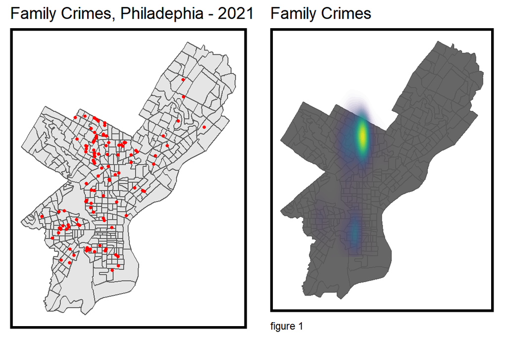

```r
# uses grid.arrange to organize indpendent plots
grid.arrange(ncol=2,
ggplot() +
  geom_sf(data = PhillyBoundary) +
  geom_sf(data = FamilyCrime, colour="red", size=1, show.legend = "point") +
  labs(title= "Family Crimes, Philadephia - 2021") +
  mapTheme(title_size = 14),

ggplot() +
  geom_sf(data = PhillyBoundary, fill = "grey40") +
  stat_density2d(data = data.frame(st_coordinates(FamilyCrime)),
                 aes(X, Y, fill = ..level.., alpha = ..level..),
                 size = 0.01, bins = 40, geom = 'polygon') +
  scale_fill_viridis() +
  scale_alpha(range = c(0.00, 0.35), guide = FALSE) +
  labs(title = "Family Crimes",
       caption = "figure 1") +
  mapTheme(title_size = 14) + theme(legend.position = "none"))
```

Figure 1 shows all the incidents of within family crime in 2021 through points and through the interpolation function. The interpolation function spreads the frequency of dots across a space to create a heat map which shows where within family crimes are located.

## Fishnet

To model crimes within family, I use a ‘fishnet’ to treat crime as an event that spans across space. In figure 2, I visualize the amount of family crimes in each small box. The two brightest points indicate where the most within family crimes occur.

```r
## using {sf} to create the grid
## Note the `.[chicagoBoundary] %>% ` line. This is needed to clip the grid to our data
fishnet <-
  st_make_grid(PhillyBoundary,
               cellsize = 500,
               square = TRUE) %>%
  .[PhillyBoundary] %>%            # <- MDH Added
  st_sf() %>%
  mutate(uniqueID = rownames(.))
```

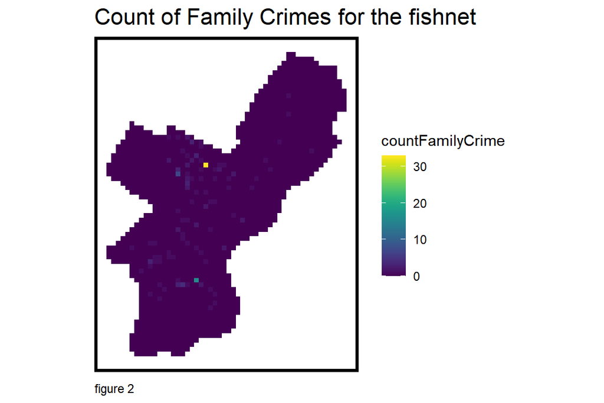

```r
## add a value of 1 to each crime, sum them with aggregate
crime_net <-
  dplyr::select(FamilyCrime) %>%
  mutate(countFamilyCrime = 1) %>%
  aggregate(., fishnet, sum) %>%
  mutate(countFamilyCrime = replace_na(countFamilyCrime, 0),
         uniqueID = rownames(.),
         cvID = sample(round(nrow(fishnet) / 24),
                       size=nrow(fishnet), replace = TRUE))

ggplot() +
  geom_sf(data = crime_net, aes(fill = countFamilyCrime), color = NA) +
  scale_fill_viridis() +
  labs(title = "Count of Family Crimes for the fishnet",
       caption = "figure 2") +
  mapTheme()
```

```r
# For demo. requires updated mapview package
# xx <- mapview::mapview(crime_net, zcol = "countBurglaries")
# yy <- mapview::mapview(mutate(burglaries, ID = seq(1:n())))
# xx + yy
```

## Modeling Spatial Features

Next we add spatial features add to the fish net. I engineered: gambling violations, amount of people of color by quintile, wards, frequency of public drunkness, frquency of rape, nearest neighbor of gambling violations, nearest neighbor of public drunkness, and nearest neighbors of incidents of rape. All other crime data was pulled from the same dataset from within family crime was pulled from.

In this model I assume gambling violations would be related to within family violence. The rationale for this is that if there’s a gambling incident then individuals may be drunk, frustrated and addicted and as such cause physical harm to their family members. Gambling violations were engineered to include the 5 nearest neighbor distances of other gambling violations. In addition to gambling violations frequencies of public drunkeness and rape were also included in the model and their respective nearest neighbors. The variables quintile percent of people of color were selected under the assumption that usually people of color are located in geographic areas with less resources than those of white people. Wards are also selected under the assumption that different wards have different geographic conditions.

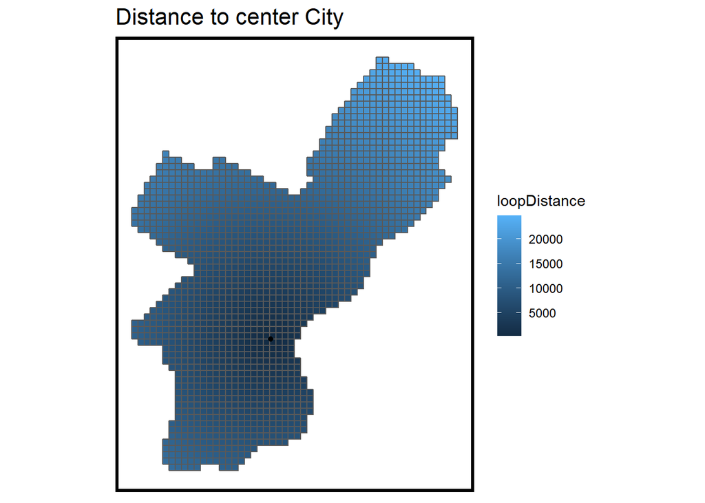

```r
## only pulling a single variable for our model to keep it simple -----------------------

GamblingViolation <- crimePhilly %>%
  filter(text_general_code == crimes[31]) %>%
  dplyr::select(hold) %>%
  st_as_sf(coords = c("lng", "lat"), crs = 4326, agr = "constant") %>%
  st_transform('ESRI:102271') %>%
    mutate(Legend = "Gambling Violations")

PublicDrunk <- crimePhilly %>%
  filter(text_general_code == crimes[29]) %>%
  dplyr::select(hold) %>%
  st_as_sf(coords = c("lng", "lat"), crs = 4326, agr = "constant") %>%
  st_transform('ESRI:102271') %>%
    mutate(Legend = "Public Drunk")

Rape <- crimePhilly %>%
  filter(text_general_code == crimes[10]) %>%
  dplyr::select(hold) %>%
  na.omit() %>%
  st_as_sf(coords = c("lng", "lat"), crs = 4326, agr = "constant") %>%
  st_transform('ESRI:102271') %>%
    mutate(Legend = "Rape") %>%
  filter(st_is_valid(.))



## Neighborhoods to use in LOOCV in a bit
neighborhoods <- st_read("https://opendata.arcgis.com/datasets/d67c97376d18456d98e5fa6e00415ad4_0.geojson") %>%
    st_transform('ESRI:102271')

acs.2019 <- PhillyBoundary %>%
              rename(White = Variables$Merge_name[1],
                     Black = Variables$Merge_name[2],
                     American_Indian = Variables$Merge_name[3],
                     Asian = Variables$Merge_name[4],
                     Native_Hawaiian_Alaskan = Variables$Merge_name[5]) %>%
              mutate(Total = rowSums(across(3:7)),
                     PoC = rowSums(across(4:7)),
                     PercentPoC = (PoC/Total)*100,
                     POCcat = q5(PercentPoC),
                     WhiteQ = q5(White),
                     BlackQ = q5(Black),
                     American_IndianQ = q5(American_Indian),
                     AsianQ = q5(Asian),
                     Native_Hawaiian_AlaskanQ = q5(Native_Hawaiian_Alaskan))

# How we aggregate a feature to our fishnet ----------------------------

vars_net_Gambling <- GamblingViolation %>%
  st_join(., fishnet, join=st_within) %>%
  st_drop_geometry() %>%
  group_by(uniqueID, Legend) %>%
  summarize(count = n()) %>%
  full_join(fishnet, by = "uniqueID") %>%
  spread(Legend, count, fill=0) %>%
  st_sf() %>%
  dplyr::select(-`<NA>`) %>%
  na.omit() %>%
  ungroup()

vars_net_PublicDrunk <- PublicDrunk %>%
  st_join(., fishnet, join=st_within) %>%
  st_drop_geometry() %>%
  group_by(uniqueID, Legend) %>%
  summarize(count = n()) %>%
  full_join(fishnet, by = "uniqueID") %>%
  spread(Legend, count, fill=0) %>%
  st_sf() %>%
  dplyr::select(-`<NA>`, -uniqueID) %>%
  na.omit() %>%
  ungroup()

vars_net_Rape <- Rape %>%
  st_join(., fishnet, join=st_within) %>%
  st_drop_geometry() %>%
  group_by(uniqueID, Legend) %>%
  summarize(count = n()) %>%
  full_join(fishnet, by = "uniqueID") %>%
  spread(Legend, count, fill=0) %>%
  st_sf() %>%
  dplyr::select(-`<NA>`, -uniqueID) %>%
  na.omit() %>%
  ungroup()

vars_net <- st_join(vars_net_Gambling, vars_net_PublicDrunk, join = st_within)
vars_net <- st_join(vars_net, vars_net_Rape, join = st_within)
# vars_net <- abandonCars %>%
#   spatially join abandonCars points to the fishnet polygon they are within %>%
#   drop the geometry attribute %>%
#   group_by each cells ID and the name of the feature %>%
#   summarize count the number of each point per grid cell %>%
#   join that summary back to spatial fishnet by cell ID %>%
#   "spread" from long to wide format and make column of our point count %>%
#   tell R that this should be an sf object %>%
#   remove a fussy column that appears b/c of NA %>%
#   get rid of rows with an NA in any column %>%
#   remove grouping so you are not tripped up later

# Distance to point

loopPoint <- neighborhoods %>%
  filter(WARD_NUM %in% c("5","8")) %>%
  st_union() %>%
  st_centroid()

vars_net$loopDistance =
  st_distance(st_centroid(vars_net),loopPoint) %>%
  as.numeric()

ggplot() +
  geom_sf(data = vars_net,
          aes(fill = loopDistance)) +
  geom_sf(data = loopPoint) +
  mapTheme() +
  labs(title = "Distance to center City")
```

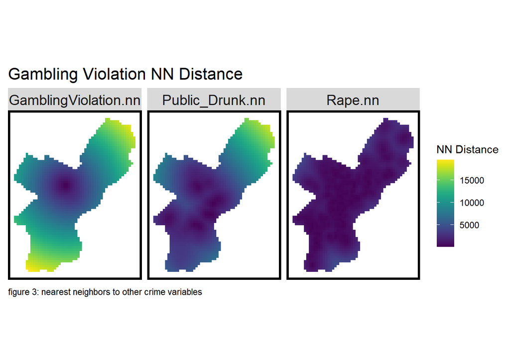

```r
## Nearest Neighbor Feature -------------------------------------

# convinience to reduce length of function names.
st_c    <- st_coordinates
st_coid <- st_centroid

Rape_st <- st_c(Rape)
## create NN from abandoned cars
vars_net<- vars_net%>%
    mutate(
      GamblingViolation.nn =
        nn_function(st_c(st_coid(vars_net)),
                                           st_c(GamblingViolation),
                                           k = 5),
      Public_Drunk.nn =
        nn_function(st_c(st_coid(vars_net)),
                                           st_c(PublicDrunk),
                                           k = 5),
      Rape.nn =
        nn_function(st_c(st_coid(vars_net)),
                                           Rape_st,
                                           k = 5))

## Visualize the NN feature ------------------
vars_net.long.nn <-
  dplyr::select(vars_net, ends_with(".nn")) %>%
    gather(Variable, value, -geometry)

ggplot() +
      geom_sf(data = vars_net.long.nn, aes(fill=value), colour=NA) +
      scale_fill_viridis(name="NN Distance") +
      labs(title="Gambling Violation NN Distance",
           caption = "figure 3: nearest neighbors to other crime variables") +
      mapTheme() +
    facet_wrap(~Variable)
```

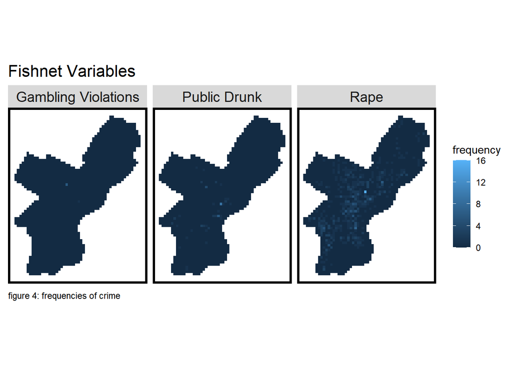

```r
vars_net %>%
  dplyr::select(-ends_with("nn")) %>%
  pivot_longer(3:5,
               names_to = "variables",
               values_to = "frequency") %>%
ggplot() +
      geom_sf(aes(fill=frequency), colour=NA) +
      labs(title="Fishnet Variables",
           caption = "figure 4: frequencies of crime") +
      mapTheme() +
      facet_wrap(~variables)
```

```r
## Join NN feature to our fishnet

# Since the counts were aggregated to each cell by `uniqueID` we can use that to join the counts to the fishnet.


## important to drop the geometry from joining features
final_net <-
  left_join(crime_net, st_drop_geometry(vars_net), by="uniqueID")

### Join in areal data ---------------------------------------
#Using spatial joins to join *centroids* of fishnets to polygon for neighborhoods and districts.

final_net <-
  st_centroid(final_net) %>%
    st_join(dplyr::select(neighborhoods, WARD_NUM), by = "uniqueID") %>%
    st_join(dplyr::select(policeDistricts, District), by = "uniqueID") %>%
    st_join(dplyr::select(acs.2019, POCcat), by = "uniqueID") %>%
#    st_join(dplyr::select(acs.2019, WhiteQ), by = "uniqueID") %>%
#    st_join(dplyr::select(acs.2019, BlackQ), by = "uniqueID") %>%
#    st_join(dplyr::select(acs.2019, American_IndianQ), by = "uniqueID") %>%
#    st_join(dplyr::select(acs.2019, AsianQ), by = "uniqueID") %>%
#    st_join(dplyr::select(acs.2019, Native_Hawaiian_AlaskanQ), by = "uniqueID") %>%
            st_drop_geometry() %>%
      left_join(dplyr::select(final_net, geometry, uniqueID)) %>%
      st_sf() %>%
  na.omit()

# for live demo
# mapview::mapview(final_net, zcol = "District")
```

After all the variables were attached to the fishnet, fixed effects such as quintile percent of people of color in each census tract were captured. Additionally, police districts and wards were also visualized to show their geographic boundaries.

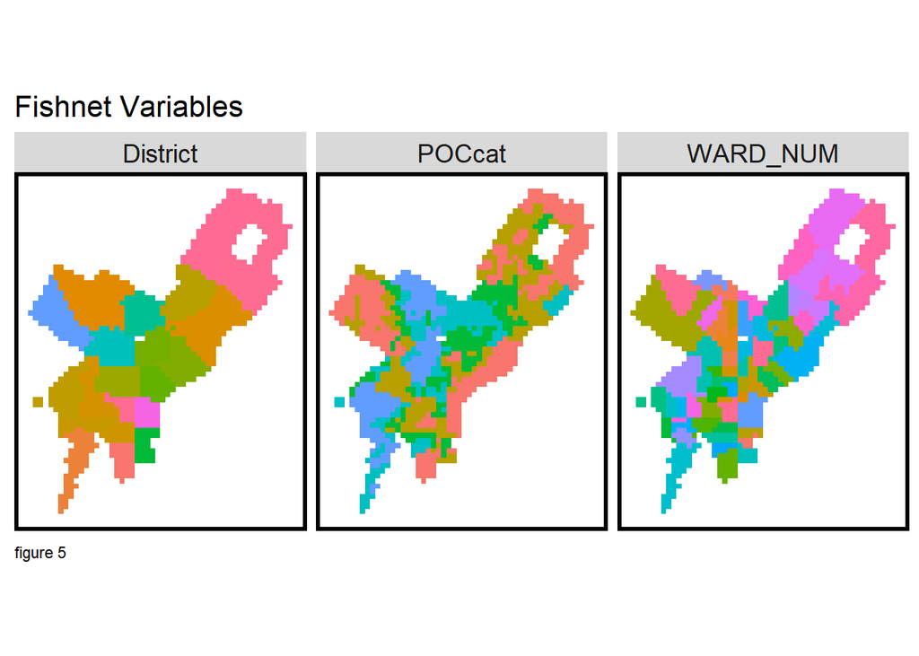

```r
final_net %>%
  dplyr::select(uniqueID, WARD_NUM, District, POCcat) %>%
  mutate(WARD_NUM = as.factor(final_net$WARD_NUM),
         District = as.factor(final_net$District)) %>%
  pivot_longer(2:4,
               names_to = "Fixed_Effects",
               values_to = "Categories") %>%
  ggplot() +
  geom_sf(aes(fill=Categories), colour=NA) +
      labs(title="Fishnet Variables",
           caption = "figure 5") +
      mapTheme() +
      facet_wrap(~Fixed_Effects) +
      theme(legend.position = "none")
```

# Local Moran’s I

Moran’s I can be calculated globally or locally, in this analysis I haven included Moran’s I locally. Global Moran’s I shows the correlation in geographic space, for example a positive/near 1 spatial autocorrelation indicates clustering, while a -1 suggests that prices are dispersed and randomly distributed. The local Moran’s I hypothesis differs from the global moran’s I in it’s null hypothesis is that the count of within family crime as a given location is randomly distributed relative to its immediate neighbors.

```r
## Local Moran's I for fishnet grid cells

#using {spdep} package to to build neighborhood weights and list to calculate local Moran's I.

#Note that the code here is *different* than in the book - it has been updated to keep up with changes in packages.
```

[output not shown]

```r
#A little in depth version of the chunk below can be found:

#Mendez C. (2020). Spatial autocorrelation analysis in R. R Studio/RPubs. Available at <https://rpubs.com/quarcs-lab/spatial-autocorrelation>



## generates warnings from PROJ issues
## {spdep} to make polygon to neighborhoods...
final_net.nb <- poly2nb(as_Spatial(final_net), queen=TRUE)
## ... and neighborhoods to list of weigths
final_net.weights <- nb2listw(final_net.nb, style="W", zero.policy=TRUE)

# print(final_net.weights, zero.policy=TRUE)

## see ?localmoran
local_morans <- localmoran(final_net$`Gambling Violations`, final_net.weights, zero.policy=TRUE) %>%
  as.data.frame()

# join local Moran's I results to fishnet
final_net.localMorans <-
  cbind(local_morans, as.data.frame(final_net)) %>%
  st_sf() %>%
  dplyr::select(Gambling_Violation_Count = `Gambling Violations`,
                Local_Morans_I = Ii,
                P_Value = `Pr(z != E(Ii))`) %>%
  mutate(Significant_Hotspots = ifelse(P_Value <= 0.001, 1, 0)) %>%
  gather(Variable, Value, -geometry)
```

In the plots below I have included the frequency of gambling violations, the local Moran’s I for gambling violations, the p-value and the singifincance hotspots. The local moran’s I indicates that there is a strong negative correlation with gambling violations locally. The p-value indicates the significance of this finding in two locations. Finally the significance hotspot shows that the single location is a hotspot. This model is helpful because a generalizable model shoul dbe able to predict regardless of hotspots or coldspots,

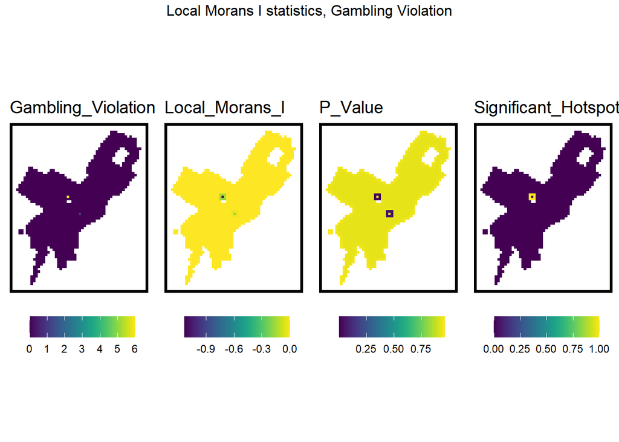

```r
### Plotting local Moran's I results

#This is a complex code chunk - it's a loop which builds ggplots of local Moran's for each of your `vars`

# What does a significant hot spot tell us about the distribution of burglaries?

## This is just for plotting
vars <- unique(final_net.localMorans$Variable)
varList <- list()

for(i in vars){
  varList[[i]] <-
    ggplot() +
      geom_sf(data = filter(final_net.localMorans, Variable == i),
              aes(fill = Value), colour=NA) +
      scale_fill_viridis(name="") +
      labs(title=i) +
      mapTheme(title_size = 14) + theme(legend.position="bottom")}

do.call(grid.arrange,c(varList, ncol = 4, top = "Local Morans I statistics, Gambling Violation"))
```

# Correlations

The correlation plots in this section are intended to show how different variables are related to each other. We want to avoid variables that are highly correlated as they will be autocorrelated and not contribute to the model. In the case of the variables that were selected, most have little to no correlation to within family crimes.

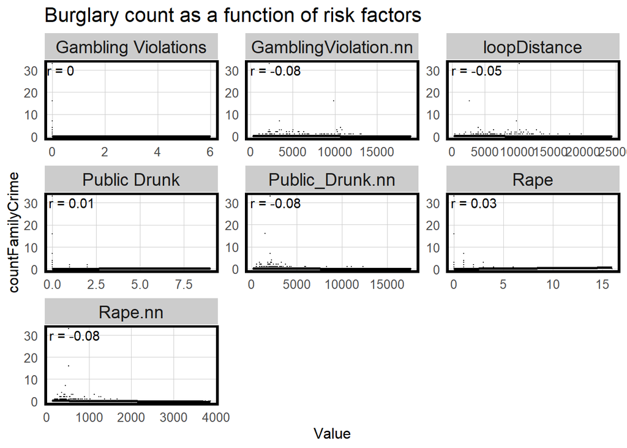

```r
correlation.long <-
  st_drop_geometry(final_net) %>%
    dplyr::select(-uniqueID, -cvID, -WARD_NUM, -District, -POCcat) %>%
    pivot_longer(2:8,names_to = "Variable", values_to = "Value")

correlation.cor <-
  correlation.long %>%
    group_by(Variable) %>%
    summarize(correlation = cor(Value, countFamilyCrime, use = "complete.obs"))

ggplot(correlation.long, aes(Value, countFamilyCrime)) +
  geom_point(size = 0.1) +
  geom_text(data = correlation.cor, aes(label = paste("r =", round(correlation, 2))),
            x=-Inf, y=Inf, vjust = 1.5, hjust = -.1) +
  geom_smooth(method = "lm", se = FALSE, colour = "black") +
  facet_wrap(~Variable, ncol = 3, scales = "free") +
  labs(title = "Burglary count as a function of risk factors") +
  plotTheme()
```

# Histogram of within Family Crimes and Poisson Distribution

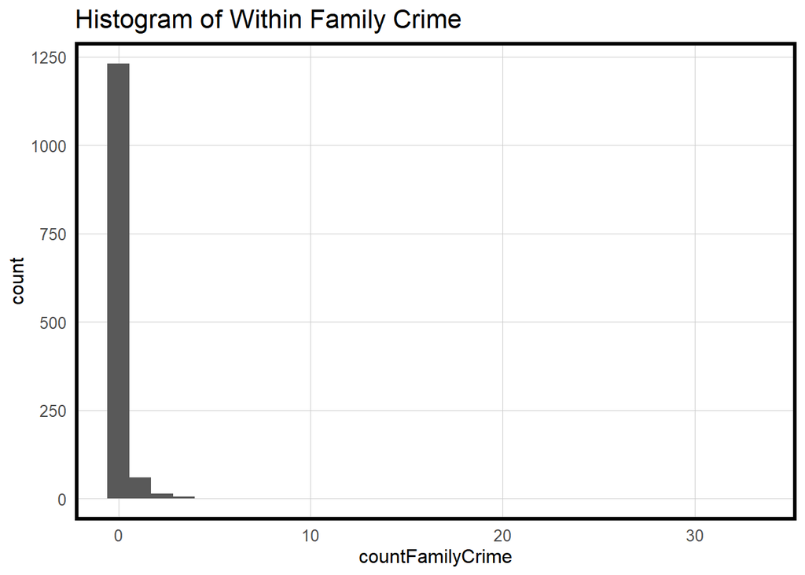

```r
final_net %>%
ggplot() +
  geom_histogram(aes(x = countFamilyCrime)) +
  plotTheme() +
  labs(title = "Histogram of Within Family Crime")
```

```r
## Distance to Hot spot

#Using NN distance to a hot spot location

# generates warning from NN
final_net <- final_net %>%
  mutate(gambling.isSig =
           ifelse(local_morans[,5] <= 0.001, 1, 0)) %>%
  mutate(gambling.isSig.dist =
           nn_function(st_c(st_coid(final_net)),
                       st_c(st_coid(filter(final_net,
                                          gambling.isSig == 1))),
                       k = 1))

## What does k = 1 represent?
```

# Model errors by random k-fold and spatial cross validation

As we build this model, we are looking for a model that is 1) able to model performance on new data, and 2) work in different spatial contexts. For the purpose of our Poisson regression, we will be directly moving to cross-validation because geospatial risk models are purely spatial. To test the models ability to test at different spatial scales, the model will hold out on one local area and train on the rest of areas. The model will iterate on this until all areas are tested. This is called Leave-one-group-out cross validation (LOGO-CV). In the case of our geographic spaces we are using Philadephia wards.

In this model, we are generating four regressions, two regressions which are just the variables, and two regressions that include spatial risk factors including moran’s I.

```r
reg.vars <- c("GamblingViolation.nn", "Public Drunk", "Gambling Violations",
              "Rape","loopDistance")

reg.ss.vars <- c("GamblingViolation.nn", "Public Drunk", "Gambling Violations",
                 "Rape", "gambling.isSig", "gambling.isSig.dist","loopDistance")
final_net <- final_net %>%
  rename(countBurglaries = countFamilyCrime)

reg.cv <- crossValidate(
  dataset = final_net,
  id = "cvID",
  dependentVariable = "countBurglaries",
  indVariables = reg.vars) %>%
    dplyr::select(cvID = cvID, countBurglaries, Prediction, geometry)

reg.ss.cv <- crossValidate(
  dataset = final_net,
  id = "cvID",
  dependentVariable = "countBurglaries",
  indVariables = reg.ss.vars) %>%
    dplyr::select(cvID = cvID, countBurglaries, Prediction, geometry)

reg.spatialCV <- crossValidate(
  dataset = final_net,
  id = "WARD_NUM",
  dependentVariable = "countBurglaries",
  indVariables = reg.vars) %>%
    dplyr::select(cvID = WARD_NUM, countBurglaries, Prediction, geometry)

reg.ss.spatialCV <- crossValidate(
  dataset = final_net,
  id = "WARD_NUM",
  dependentVariable = "countBurglaries",
  indVariables = reg.ss.vars) %>%
    dplyr::select(cvID = WARD_NUM, countBurglaries, Prediction, geometry)


reg.summary <-
  rbind(
    mutate(reg.cv,           Error = Prediction - countBurglaries,
                             Regression = "Random k-fold CV: Just Risk Factors"),

    mutate(reg.ss.cv,        Error = Prediction - countBurglaries,
                             Regression = "Random k-fold CV: Spatial Process"),

    mutate(reg.spatialCV,    Error = Prediction - countBurglaries,
                             Regression = "Spatial LOGO-CV: Just Risk Factors"),

    mutate(reg.ss.spatialCV, Error = Prediction - countBurglaries,
                             Regression = "Spatial LOGO-CV: Spatial Process")) %>%
    st_sf()
```

# Raw Errors: Wards

The histograms below are created from an object called `error_by_reg_and_fold`. This object calculates and visualizes and mean average error for each fold across each regression. From the model that I built, there seems to be very little difference even when taking into account spatial factors.

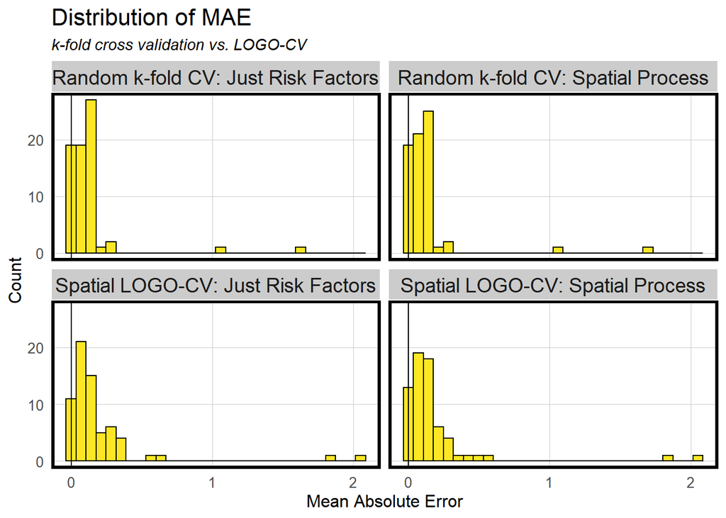

```r
error_by_reg_and_fold <-
  reg.summary %>%
    group_by(Regression, cvID) %>%
    summarize(Mean_Error = mean(Prediction - countBurglaries, na.rm = T),
              MAE = mean(abs(Mean_Error), na.rm = T),
              SD_MAE = mean(abs(Mean_Error), na.rm = T)) %>%
  ungroup()

error_by_reg_and_fold %>%
  ggplot(aes(MAE)) +
    geom_histogram(bins = 30, colour="black", fill = "#FDE725FF") +
    facet_wrap(~Regression) +
    geom_vline(xintercept = 0) + scale_x_continuous(breaks = seq(0, 8, by = 1)) +
    labs(title="Distribution of MAE", subtitle = "k-fold cross validation vs. LOGO-CV",
         x="Mean Absolute Error", y="Count") +
    plotTheme()
```

```r
st_drop_geometry(error_by_reg_and_fold) %>%
  group_by(Regression) %>%
    summarize(Mean_MAE = round(mean(MAE), 2),
              SD_MAE = round(sd(MAE), 2)) %>%
  kable() %>%
    kable_styling("striped", full_width = F) %>%
    row_spec(2, color = "black", background = "#FDE725FF") %>%
    row_spec(4, color = "black", background = "#FDE725FF")
```

| Regression | Mean_MAE | SD_MAE |
| --- | --- | --- |
| Random k-fold CV: Just Risk Factors | 0.12 | 0.23 |
| Random k-fold CV: Spatial Process | 0.12 | 0.23 |
| Spatial LOGO-CV: Just Risk Factors | 0.19 | 0.34 |
| Spatial LOGO-CV: Spatial Process | 0.18 | 0.33 |

The figure below visualizes the LOGO-CV errors spatially. In this case the most error is in the areas where there are incidents of family crimes.

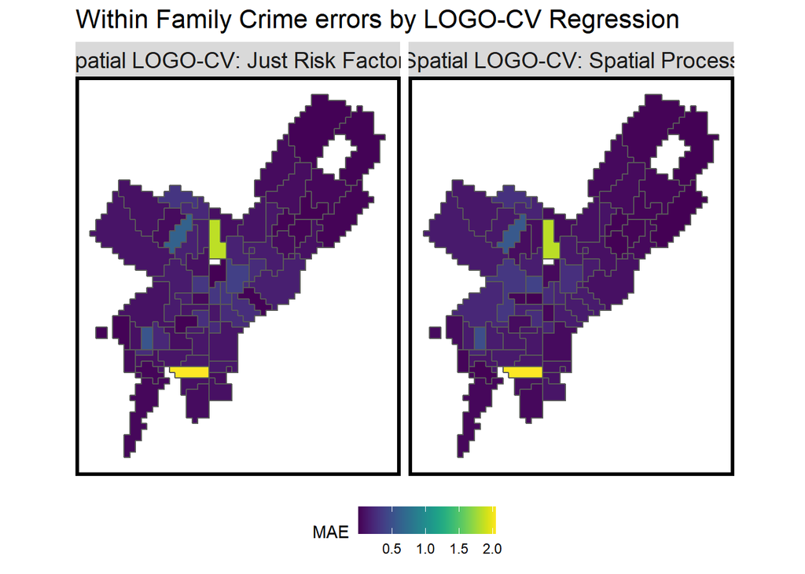

```r
error_by_reg_and_fold %>%
  filter(str_detect(Regression, "LOGO")) %>%
  ggplot() +
    geom_sf(aes(fill = MAE)) +
    facet_wrap(~Regression) +
    scale_fill_viridis() +
    labs(title = "Within Family Crime errors by LOGO-CV Regression") +
    mapTheme() + theme(legend.position="bottom")
```

# Raw Errors: Race

In the model above the categorical variable that is used for the leave one group out cross validation, is ward, in the example below, I include the MAE for racial category on whether they are white or not. In this study people of color was everyone who was not white.

Overall the model does not show that there are siginificant differences between using risk factors or considering sptaial processes when using LOGO-CV.

```r
tracts18 <-
  get_acs(geography = "tract", variables = c("B01001_001E","B01001A_001E"),
          year = 2019, state="PA", county= "Philadelphia", geometry=T) %>%
  st_transform('ESRI:102271')  %>%
  dplyr::select(variable, estimate, GEOID) %>%
  spread(variable, estimate) %>%
  rename(TotalPop = B01001_001,
         NumberWhites = B01001A_001) %>%
  mutate(percentWhite = NumberWhites / TotalPop,
         raceContext = ifelse(percentWhite > .5, "Majority_White", "Majority_Non_White")) %>%
  .[neighborhoods,]


reg.summary %>%
  filter(str_detect(Regression, "LOGO")) %>%
    st_centroid() %>%
    st_join(tracts18) %>%
    na.omit() %>%
      st_drop_geometry() %>%
      group_by(Regression, raceContext) %>%
      summarize(mean.Error = mean(Error, na.rm = T)) %>%
      spread(raceContext, mean.Error) %>%
      kable(caption = "Mean Error by neighborhood racial context") %>%
        kable_styling("striped", full_width = F)
```

Mean Error by neighborhood racial context

| Regression | Majority_Non_White | Majority_White |
| --- | --- | --- |
| Spatial LOGO-CV: Just Risk Factors | -0.0845253 | 0.0722724 |
| Spatial LOGO-CV: Spatial Process | -0.0726925 | 0.0703102 |

# Density vs predictions

This section shows visuals using the kernel density function at different widths.

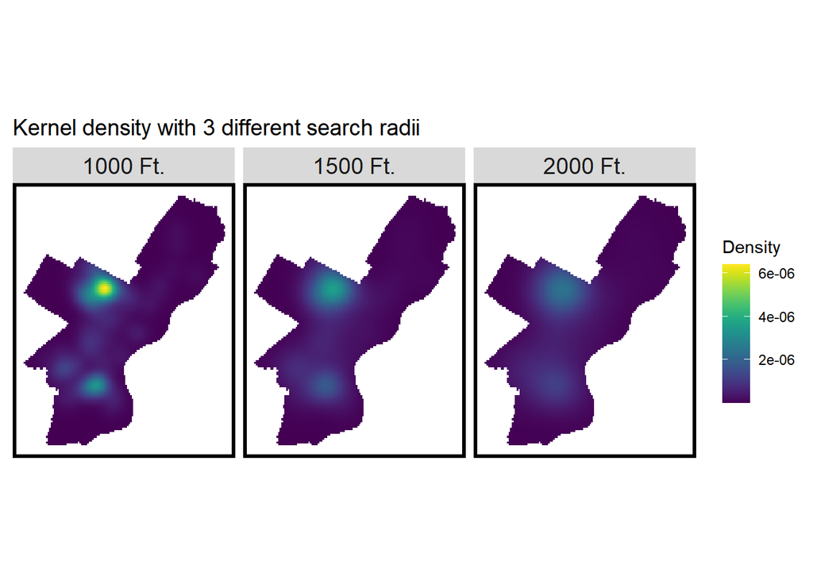

```r
# demo of kernel width
burg_ppp <- as.ppp(st_coordinates(FamilyCrime), W = st_bbox(final_net))
burg_KD.1000 <- spatstat.core::density.ppp(burg_ppp, 1000)
burg_KD.1500 <- spatstat.core::density.ppp(burg_ppp, 1500)
burg_KD.2000 <- spatstat.core::density.ppp(burg_ppp, 2000)
burg_KD.df <- rbind(
  mutate(data.frame(rasterToPoints(mask(raster(burg_KD.1000), as(neighborhoods, 'Spatial')))), Legend = "1000 Ft."),
  mutate(data.frame(rasterToPoints(mask(raster(burg_KD.1500), as(neighborhoods, 'Spatial')))), Legend = "1500 Ft."),
  mutate(data.frame(rasterToPoints(mask(raster(burg_KD.2000), as(neighborhoods, 'Spatial')))), Legend = "2000 Ft."))

burg_KD.df$Legend <- factor(burg_KD.df$Legend, levels = c("1000 Ft.", "1500 Ft.", "2000 Ft."))

ggplot(data=burg_KD.df, aes(x=x, y=y)) +
  geom_raster(aes(fill=layer)) +
  facet_wrap(~Legend) +
  coord_sf(crs=st_crs(final_net)) +
  scale_fill_viridis(name="Density") +
  labs(title = "Kernel density with 3 different search radii") +
  mapTheme(title_size = 14)
```

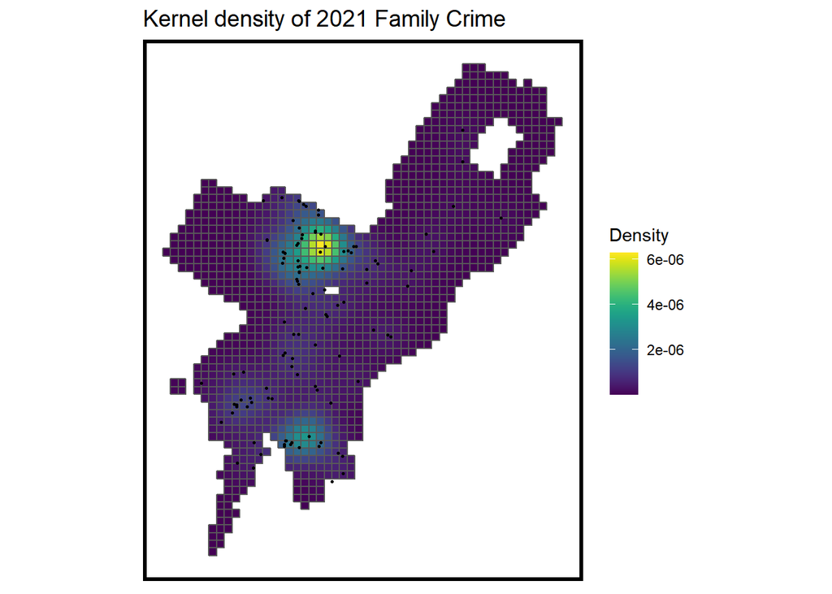

```r
as.data.frame(burg_KD.1000) %>%
  st_as_sf(coords = c("x", "y"), crs = st_crs(final_net)) %>%
  aggregate(., final_net, mean) %>%
   ggplot() +
     geom_sf(aes(fill=value)) +
     geom_sf(data = sample_n(FamilyCrime, 169), size = .5) +
     scale_fill_viridis(name = "Density") +
     labs(title = "Kernel density of 2021 Family Crime") +
     mapTheme(title_size = 14)
```

# Testing the model on 2018 data

To check the accuracy and generalizability of my model, I will be comparing predictions to the 2018 data. I compiled the 2018 data from the same location as the 2021 data.

In comparing the model built from 2021 data and comparing to kernel density from 2018, the model does not seem to predict very well. The Kernel Density model is able to find locations in South Philly, that the model is not able to pick up on.

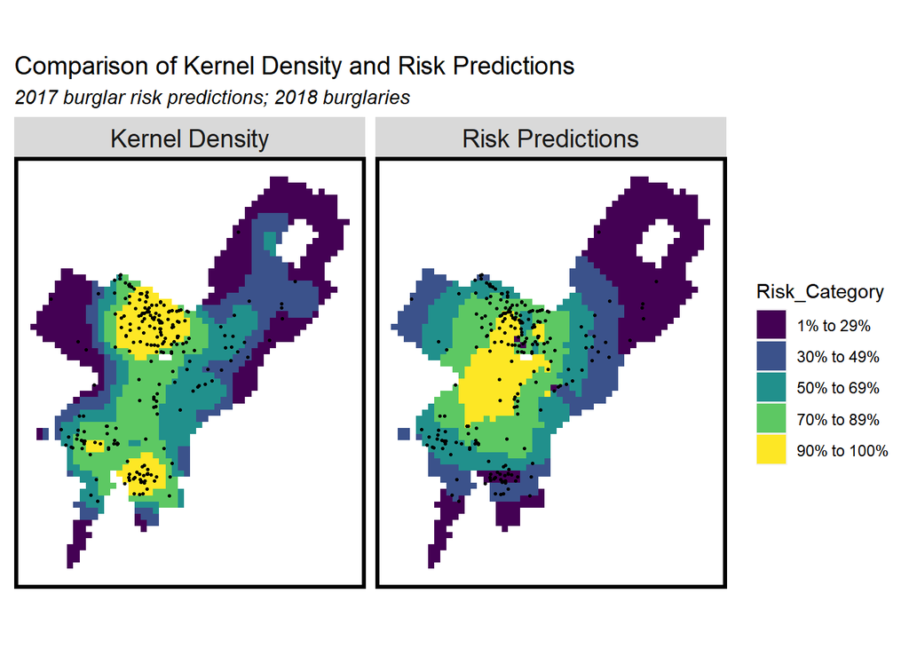

```r
#crimePhilly18 <- read.csv("https://phl.carto.com/api/v2/sql?filename=incidents_part1_part2&format=csv&q=SELECT%20*%20,%20ST_Y(the_geom)%20AS%20lat,%20ST_X(the_geom)%20AS%20lng%20FROM%20incidents_part1_part2%20WHERE%20dispatch_date_time%20%3E=%20%272020-01-01%27%20AND%20dispatch_date_time%20%3C%20%272021-01-01%27")

FamilyCrime18 <- read.csv("crimePhilly18.csv") %>%
  filter(text_general_code == crimes[22]) %>%
  dplyr::select(hold) %>%
  st_as_sf(coords = c("lng", "lat"), crs = 4326, agr = "constant") %>%
  st_transform('ESRI:102271')  %>%
  na.omit %>%
  distinct() %>%
  .[fishnet,]

burg_KDE_sf <- as.data.frame(burg_KD.1000) %>%
  st_as_sf(coords = c("x", "y"), crs = st_crs(final_net)) %>%
  aggregate(., final_net, mean) %>%
  mutate(label = "Kernel Density",
         Risk_Category = ntile(value, 100),
         Risk_Category = case_when(
           Risk_Category >= 90 ~ "90% to 100%",
           Risk_Category >= 70 & Risk_Category <= 89 ~ "70% to 89%",
           Risk_Category >= 50 & Risk_Category <= 69 ~ "50% to 69%",
           Risk_Category >= 30 & Risk_Category <= 49 ~ "30% to 49%",
           Risk_Category >= 1 & Risk_Category  <= 29 ~ "1% to 29%")) %>%
  cbind(
    aggregate(
      dplyr::select(FamilyCrime18) %>% mutate(burgCount = 1), ., sum) %>%
    mutate(burgCount = replace_na(burgCount, 0))) %>%
  dplyr::select(label, Risk_Category, burgCount)

burg_risk_sf <-
  reg.ss.spatialCV %>%
  mutate(label = "Risk Predictions",
         Risk_Category = ntile(Prediction, 100),
         Risk_Category = case_when(
         Risk_Category >= 90 ~ "90% to 100%",
         Risk_Category >= 70 & Risk_Category <= 89 ~ "70% to 89%",
         Risk_Category >= 50 & Risk_Category <= 69 ~ "50% to 69%",
         Risk_Category >= 30 & Risk_Category <= 49 ~ "30% to 49%",
         Risk_Category >= 1 & Risk_Category <= 29 ~ "1% to 29%")) %>%
  cbind(
    aggregate(
      dplyr::select(FamilyCrime18) %>% mutate(burgCount = 1), ., sum) %>%
      mutate(burgCount = replace_na(burgCount, 0))) %>%
  dplyr::select(label,Risk_Category, burgCount)

rbind(burg_KDE_sf, burg_risk_sf) %>%
  na.omit() %>%
  gather(Variable, Value, -label, -Risk_Category, -geometry) %>%
  ggplot() +
    geom_sf(aes(fill = Risk_Category), colour = NA) +
    geom_sf(data = sample_n(FamilyCrime18, 411), size = .5, colour = "black") +
    facet_wrap(~label, ) +
    scale_fill_viridis(discrete = TRUE) +
    labs(title="Comparison of Kernel Density and Risk Predictions",
         subtitle="2017 burglar risk predictions; 2018 burglaries") +
    mapTheme(title_size = 14)
```

The plot below shows the how well the model predicts on a histogram in comparison to the kernel density function, which provides more specifics to how the model does not predict well. For example, in areas where there is more likely to be within family crime, it underpredicts, in contrast to when there are low risk categories, it over predicts in these areas.

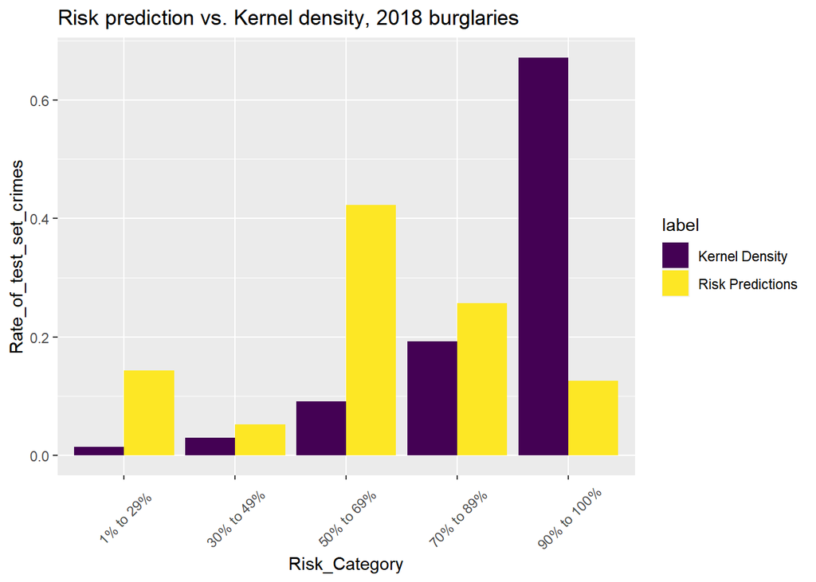

```r
rbind(burg_KDE_sf, burg_risk_sf) %>%
  st_set_geometry(NULL) %>% na.omit() %>%
  gather(Variable, Value, -label, -Risk_Category) %>%
  group_by(label, Risk_Category) %>%
  summarize(countBurglaries = sum(Value)) %>%
  ungroup() %>%
  group_by(label) %>%
  mutate(Rate_of_test_set_crimes = countBurglaries / sum(countBurglaries)) %>%
    ggplot(aes(Risk_Category,Rate_of_test_set_crimes)) +
      geom_bar(aes(fill=label), position="dodge", stat="identity") +
      scale_fill_viridis(discrete = TRUE) +
      labs(title = "Risk prediction vs. Kernel density, 2018 burglaries") +
      theme(axis.text.x = element_text(angle = 45, vjust = 0.5))
```

# Conclusion

Based on the current variables in the model, I would not recommend this model. When comparing this map to kernel densities, this data does not seem to predict well in any comparison of the histogram. Additionally, even when this model is compared against a normal regression that does not take into account spatial variables, the model is about the same in predictive power. The model tends to underpredict higher rates of crime per area, while over predicting crime in for everything lower than 89%.

Overall this model will need to continue being worked on. Although there has been literature that has shown the relationship between with within family crime and other factors, this model does not do a good job modeling the risk. One of the reasons for this, is that within family crime does not occur very frequently and are rare across the city. Additionally, the assumptions that are made about indicators of family crime do not indicate any positive or negative correlation, nor are there are any spatial relationships. If anything, this report does address the challenges in trying to identify an indicator that predicts risk of within family crime.

# Appendix

## Modeling and CV

Leave One Group Out CV on spatial features

### Ward Number

```r
# View(crossValidate)

## define the variables we want
reg.ss.vars <- c("GamblingViolation.nn", "gambling.isSig.dist")

## RUN REGRESSIONS
reg.ss.spatialCV <- crossValidate(
  dataset = final_net,
  id = "WARD_NUM",
  dependentVariable = "countBurglaries",
  indVariables = reg.ss.vars) %>%
    dplyr::select(WARD_NUM, countBurglaries, Prediction, geometry)
```

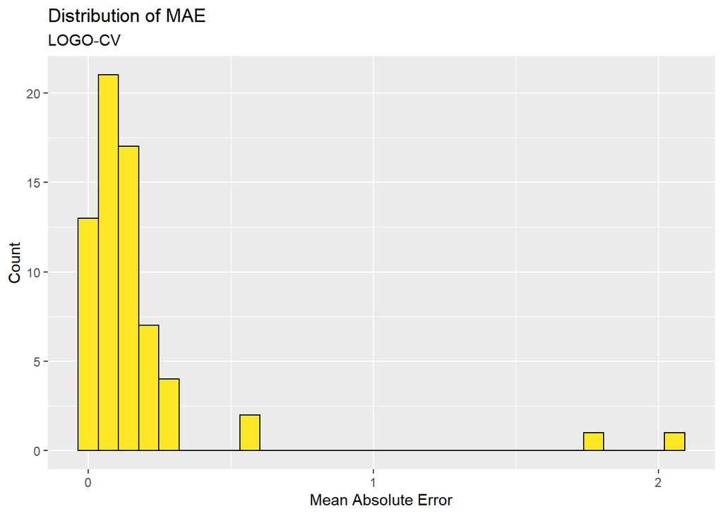

```r
# calculate errors by NEIGHBORHOOD
error_by_reg_and_fold <-
  reg.ss.spatialCV %>%
    group_by(WARD_NUM) %>%
    summarize(Mean_Error = mean(Prediction - countBurglaries, na.rm = T),
              MAE = mean(abs(Mean_Error), na.rm = T),
              SD_MAE = mean(abs(Mean_Error), na.rm = T)) %>%
  ungroup()

A <- error_by_reg_and_fold %>%
  arrange(desc(MAE)) %>%
  st_drop_geometry()

datatable(A)

A <- error_by_reg_and_fold %>%
  arrange(MAE) %>%
  st_drop_geometry()

datatable(A)

## plot histogram of OOF (out of fold) errors
error_by_reg_and_fold %>%
  ggplot(aes(MAE)) +
    geom_histogram(bins = 30, colour="black", fill = "#FDE725FF") +
  scale_x_continuous(breaks = seq(0, 11, by = 1)) +
    labs(title="Distribution of MAE", subtitle = "LOGO-CV",
         x="Mean Absolute Error", y="Count")
```

### Police District

```r
# View(crossValidate)

## RUN REGRESSIONS
reg.ss.spatialCV <- crossValidate(
  dataset = final_net,
  id = "District",
  dependentVariable = "countBurglaries",
  indVariables = reg.ss.vars) %>%
    dplyr::select(District, countBurglaries, Prediction, geometry)
```

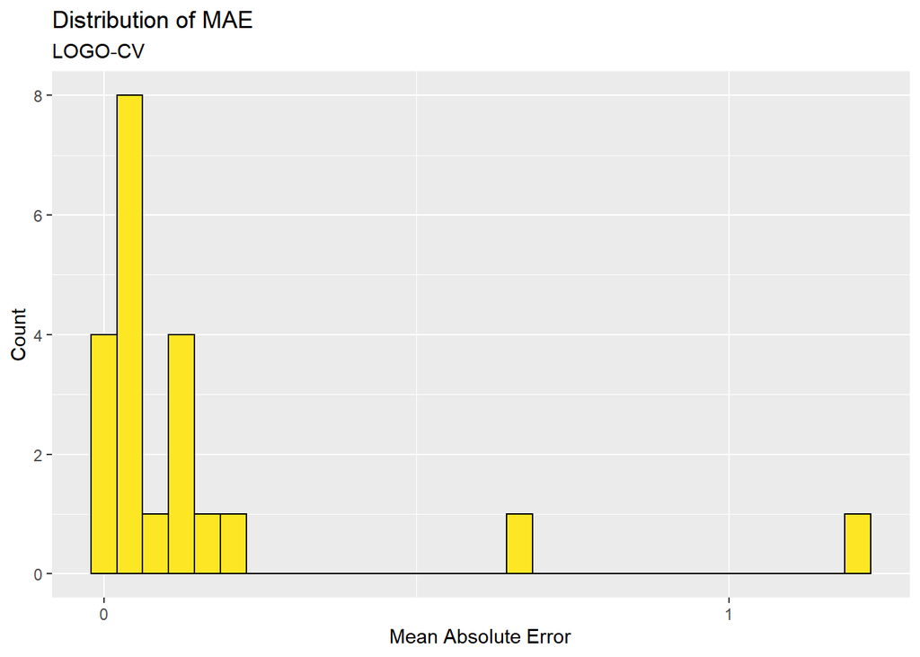

```r
# calculate errors by NEIGHBORHOOD
error_by_reg_and_fold <-
  reg.ss.spatialCV %>%
    group_by(District) %>%
    summarize(Mean_Error = mean(Prediction - countBurglaries, na.rm = T),
              MAE = mean(abs(Mean_Error), na.rm = T),
              SD_MAE = mean(abs(Mean_Error), na.rm = T)) %>%
  ungroup()

A <- error_by_reg_and_fold %>%
  arrange(desc(MAE)) %>%
  st_drop_geometry()

datatable(A)

A <- error_by_reg_and_fold %>%
  arrange(MAE) %>%
  st_drop_geometry()

datatable(A)

## plot histogram of OOF (out of fold) errors
error_by_reg_and_fold %>%
  ggplot(aes(MAE)) +
    geom_histogram(bins = 30, colour="black", fill = "#FDE725FF") +
  scale_x_continuous(breaks = seq(0, 11, by = 1)) +
    labs(title="Distribution of MAE", subtitle = "LOGO-CV",
         x="Mean Absolute Error", y="Count")
```

```r
# View(crossValidate)

## RUN REGRESSIONS
reg.ss.spatialCV <- crossValidate(
  dataset = final_net,
  id = "POCcat",
  dependentVariable = "countBurglaries",
  indVariables = reg.ss.vars) %>%
    dplyr::select(POCcat, countBurglaries, Prediction, geometry)
```

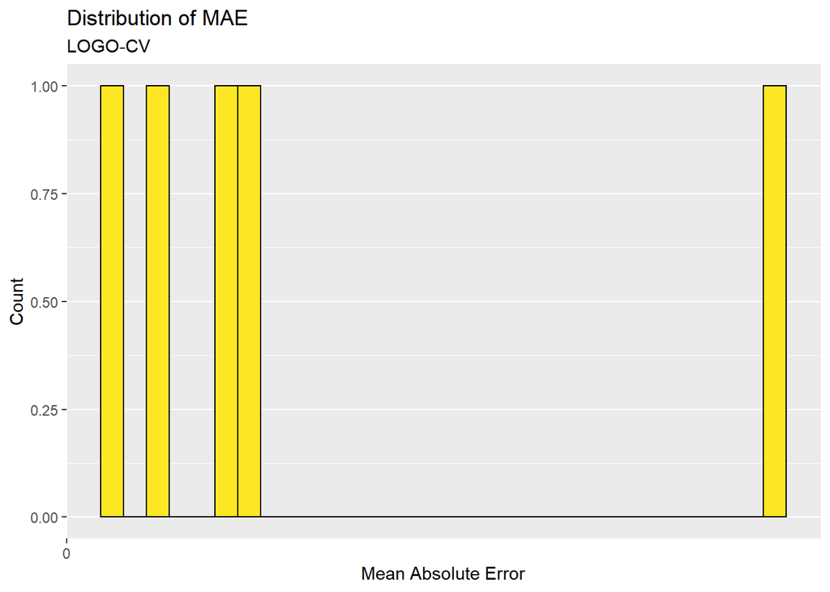

```r
# calculate errors by NEIGHBORHOOD
error_by_reg_and_fold <-
  reg.ss.spatialCV %>%
    group_by(POCcat) %>%
    summarize(Mean_Error = mean(Prediction - countBurglaries, na.rm = T),
              MAE = mean(abs(Mean_Error), na.rm = T),
              SD_MAE = mean(abs(Mean_Error), na.rm = T)) %>%
  ungroup()

A <- error_by_reg_and_fold %>%
  arrange(desc(MAE)) %>%
  st_drop_geometry()

datatable(A)

A <- error_by_reg_and_fold %>%
  arrange(MAE) %>%
  st_drop_geometry()

datatable(A)

## plot histogram of OOF (out of fold) errors
error_by_reg_and_fold %>%
  ggplot(aes(MAE)) +
    geom_histogram(bins = 30, colour="black", fill = "#FDE725FF") +
  scale_x_continuous(breaks = seq(0, 11, by = 1)) +
    labs(title="Distribution of MAE", subtitle = "LOGO-CV",
         x="Mean Absolute Error", y="Count")
```

# Sources

Butterfield, Fox. 2018. “When Crime Is a Family Affair.” The Atlantic. October 22, 2018. https://www.theatlantic.com/family/archive/2018/10/crime-runs-family/573394/.